# Paper 1 notebook

```r
source("utils.R")
source("notebook_utils.R")# load in utility functions
require(lme4)
require(tidyr)
# for presentation.
require(ggfortify)
require(Hmisc)
# for missingness.
require(tidyr)
require(VIM)
require(mice)
require(lattice) # for histogram.
require(laeken) # for weighedMean.
# for extrapolation.
require(tidyr)
require(glmnet)
# for heterogeneity.
require(tidyr)
require(glmnet)
require(geepack)
require(lme4)
require(MuMIn)
```

## Baseline

```r
# Preprocessing data.


data <- format_baseline_data("/Users/robertclay/paper1/data/corrected_US/", c(2011,2012,2013))
summary(data)
```

```
      pidp               SF.12          job_sec        education_state
 Min.   :2.244e+04   Min.   : 0.00   Min.   :-10.000   Length:129406
 1st Qu.:3.679e+08   1st Qu.:43.99   1st Qu.:-10.000   Class :character
 Median :7.080e+08   Median :51.77   Median :  3.000   Mode  :character
 Mean   :7.694e+08   Mean   :49.45   Mean   : -1.609
 3rd Qu.:1.157e+09   3rd Qu.:57.06   3rd Qu.:  5.000
 Max.   :1.653e+09   Max.   :78.08   Max.   :  8.000
                     NA's   :19997   NA's   :278
     sex            labour_state          region
 Length:129406      Length:129406      Length:129406
 Class :character   Class :character   Class :character
 Mode  :character   Mode  :character   Mode  :character




  ethnicity              age              time      gross_hh_income
 Length:129406      Min.   : 16.00   Min.   :2011   Min.   :-15967
 Class :character   1st Qu.: 34.00   1st Qu.:2011   1st Qu.:  1867
 Mode  :character   Median : 48.00   Median :2012   Median :  3113
                    Mean   : 48.19   Mean   :2012   Mean   :  3771
                    3rd Qu.: 62.00   3rd Qu.:2013   3rd Qu.:  4906
                    Max.   :104.00   Max.   :2013   Max.   :735592
                    NA's   :4
```

```r
# Rescale continuous variables
scaled_variables <- c("age", "gross_hh_income", "SF.12")
data[,scaled_variables] <- scale(data[,scaled_variables])

# Convert discrete variables to factors.
#data$depression_change <- factor(data$depression_change, ordered=T)

data <- tidyr::drop_na(data)
n <- nrow(data)
set.seed(88)
Inx <- sample(n, 0.8*n)
train<-data[Inx,]
test<-data[-Inx,]

y <- train$depression
y2<- test$depression
```

Baseline data analysis for SF.12

```r
sf12.lm <- lm(SF.12 ~ factor(sex) +
               factor(ethnicity) +
               age +
               factor(education_state) +
               factor(labour_state) +
               factor(job_sec) +
               factor(region) +
               gross_hh_income,
               data= train)

preds <- predict(sf12.lm, test)

a<- summary(sf12.lm)
print(a)
```

```
Call:
lm(formula = SF.12 ~ factor(sex) + factor(ethnicity) + age +
    factor(education_state) + factor(labour_state) + factor(job_sec) +
    factor(region) + gross_hh_income, data = train)

Residuals:
    Min      1Q  Median      3Q     Max
-9.1087 -0.5164  0.1962  0.6592  3.6337

Coefficients:
                                          Estimate Std. Error t value
(Intercept)                             -1.638e-01  3.966e-02  -4.130
factor(sex)Male                          1.899e-01  6.746e-03  28.145
factor(ethnicity)BLA                     1.992e-01  3.832e-02   5.199
factor(ethnicity)BLC                     4.306e-02  3.922e-02   1.098
factor(ethnicity)CHI                     3.475e-02  5.911e-02   0.588
factor(ethnicity)IND                     7.194e-02  3.529e-02   2.039
factor(ethnicity)MIX                    -7.791e-02  3.895e-02  -2.000
factor(ethnicity)OAS                    -3.240e-02  4.147e-02  -0.781
factor(ethnicity)OBL                     1.365e-01  9.028e-02   1.512
factor(ethnicity)OTH                     3.499e-02  6.212e-02   0.563
factor(ethnicity)PAK                    -4.129e-02  3.707e-02  -1.114
factor(ethnicity)WBI                     2.674e-02  3.050e-02   0.877
factor(ethnicity)WHO                     1.644e-02  3.386e-02   0.486
age                                      1.505e-01  5.507e-03  27.331
factor(education_state)CSE               4.199e-05  1.948e-02   0.002
factor(education_state)Degree            2.143e-02  1.282e-02   1.671
factor(education_state)GCSE              4.969e-02  1.120e-02   4.435
factor(education_state)HE Diploma        4.237e-02  1.467e-02   2.888
factor(education_state)Higher Degree     5.359e-02  1.377e-02   3.893
factor(education_state)Less than GCSE   -4.389e-02  1.199e-02  -3.660
factor(labour_state)Family Care         -1.050e-01  2.512e-02  -4.180
factor(labour_state)Government Training -3.552e-02  1.393e-01  -0.255
factor(labour_state)Maternity Leave      8.019e-02  4.408e-02   1.819
factor(labour_state)Other               -1.798e-01  5.191e-02  -3.464
factor(labour_state)Retired              1.443e-01  2.339e-02   6.169
factor(labour_state)Self-employed        3.780e-02  1.859e-02   2.033
factor(labour_state)Sick/Disabled       -1.182e+00  2.749e-02 -42.991
factor(labour_state)Student              9.385e-02  2.184e-02   4.296
factor(labour_state)Unemployed          -3.685e-01  2.554e-02 -14.428
```

[output cut: 61 more lines]

```
factor(region)North West                0.145033
factor(region)Northern Ireland          0.000186 ***
factor(region)Scotland                  0.020179 *
factor(region)South East                0.884454
factor(region)South West                0.064890 .
factor(region)Wales                     0.673492
factor(region)West Midlands             0.002790 **
factor(region)Yorkshire and The Humber  0.797183
gross_hh_income                          < 2e-16 ***
---
Signif. codes:  0 ‘***’ 0.001 ‘**’ 0.01 ‘*’ 0.05 ‘.’ 0.1 ‘ ’ 1

Residual standard error: 0.9464 on 87237 degrees of freedom
Multiple R-squared:  0.1069,    Adjusted R-squared:  0.1064
F-statistic: 217.6 on 48 and 87237 DF,  p-value: < 2.2e-16
```

```r
print(a$adj.r.squared)
```

```
[1] 0.1064225
```

```r
pdf("../plots/SF12_residuals.pdf")
plot(residuals(sf12.lm))
dev.off()
```

## Presentation

assess assumptions of linear model for SF.12. see 4 plots Residuals vs Fitted. Used to check the linear relationship assumptions. A horizontal line, without distinct patterns is an indication for a linear relationship, what is good.

Normal Q-Q. Used to examine whether the residuals are normally distributed. It’s good if residuals points follow the straight dashed line.

Scale-Location (or Spread-Location). Used to check the homogeneity of variance of the residuals (homoscedasticity). Horizontal line with equally spread points is a good indication of homoscedasticity. This is not the case in our example, where we have a heteroscedasticity problem.

Residuals vs Leverage. Used to identify influential cases, that is extreme values that might influence the regression results when included or excluded from the analysis.

```r
pdf("../plots/first_sf12_dist.pdf")
hist(train$SF.12)
dev.off()

pdf("../plots/SF12_residuals.pdf")
hist(residuals(sf12.lm))
dev.off()

pdf("../plots/SF12_diagnostics.pdf")
autoplot(sf12.lm)
dev.off()
```

see residuals and leverage stable aparat from extreme outliers. qq plot does okay but deviates on left tail. suggests over estimating more depressed individual SF12 scores. scale location clearly non constant. suggests heteroscedasticity which would be expected in data with repeat observations like this.

There are obvious highly extreme values here. See major leverage values for observations with index 92349 and 71315 (PID 884636487 and 681114527). In this case it is due to individuals suddenly experiencing over 10x increases in income. Their SF12 score is majorly over estimated.

Removing from the data..

```r
train2 <- train[(which(train$pidp %nin% c(884636487, 681114527, 750749251, 68397127, 1361073051, 1088667767))),]
sf12.lm2<-lm(SF.12 ~ factor(sex) +
                    factor(ethnicity) +
                    age +
                    factor(education_state) +
                     factor(labour_state) +
                     factor(job_sec) +
                      gross_hh_income,
                       data= train2)
print(summary(sf12.lm2))

pdf("../plots/no_outliers_sf12_residuals.pdf")
hist(residuals(sf12.lm2))
dev.off()

pdf("../plots/no_outliers_diagnostics.pdf")
autoplot(sf12.lm2)
dev.off()
```

# Missingness

Structure of missingness. clear vast majority of missing are in depression states. rest of states have low enough percentages to impute via MI. 35922 entries total.

```r
# Preprocessing data.


data <- format_baseline_data("/Users/robertclay/paper1/data/corrected_US/", c(2011,2012,2013))
summary(data)
# Rescale continuous variables
scaled_variables <- c("age", "gross_hh_income", "SF.12")
data[,scaled_variables] <- scale(data[,scaled_variables])

# Convert discrete variables to factors.
#data$depression_change <- factor(data$depression_change, ordered=T)

n <- nrow(data)
set.seed(88)
Inx <- sample(n, 0.8*n)
train<-data[Inx,]
test<-data[-Inx,]

y <- train$depression
y2<- test$depression
```

```r
pdf("../plots/total_missingness_structure.pdf")
aggr(data, numbers=T, cex.axis=0.5, col = c(blue, orange))
```

```
not enough horizontal space to display frequencies
```

```r
dev.off()
```

```r
pdf("../plots/ethnicity_SF12_spinogram.pdf")
```

```r
spineMiss(data[, c("ethnicity", "SF.12")], col = c(blue, orange))
dev.off()
```

```r
pdf("../plots/age_SF12_spinogram.pdf")
```

```r
spineMiss(data[, c("age", "SF.12")], col = c(blue, orange))
dev.off()
```

```r
pdf("../plots/jbsec_SF12_spinogram.pdf")
```

```r
spineMiss(data[, c("job_sec", "SF.12")], col = c(blue, orange))
dev.off()
```

```r
pdf("../plots/labour_SF12_spinogram.pdf")
```

```r
spineMiss(data[, c("labour_state", "SF.12")], col = c(blue, orange))
dev.off()
```

see same for continuous variables

```r
is_missing_sf12 <- is.na(data$SF.12)
is_missing_dep <- is.na(data$depression)
is_missing_depc <- is.na(data$depression_change)

pdf("../plots/age_SF12_histograms.pdf")
histogram(~age|is_missing_sf12, data)
dev.off()
pdf("../plots/age_HLPRB_histograms.pdf")
histogram(~age|is_missing_dep, data)
dev.off()

pdf("../plots/age_GHQ_histograms.pdf")
histogram(~age|is_missing_depc, data)
dev.off()

# do this for household too?
```

MICE

```r
imp_columns <- c("SF.12","labour_state", "age", "sex", "ethnicity", "job_sec", "education_state", "region", "gross_hh_income")
meth<- c("norm", 'rfcat')
mice_set <- mice(data = data[, imp_columns],
                 m = 10, maxit = 10, seed = 88, remove_colinear=F)
```

```
Number of logged events: 5
```

```r
print(summary(complete(mice_set)))
```

```
     SF.12       labour_state            age             sex             ethnicity            job_sec
 Min.   :-4.99   Length:129406      Min.   :-1.742   Length:129406      Length:129406      Min.   :-10.00
 1st Qu.:-0.56   Class :character   1st Qu.:-0.768   Class :character   Class :character   1st Qu.:-10.00
 Median : 0.23   Mode  :character   Median :-0.010   Mode  :character   Mode  :character   Median :  3.00
 Mean   : 0.00                      Mean   : 0.000                                         Mean   : -1.61
 3rd Qu.: 0.77                      3rd Qu.: 0.748                                         3rd Qu.:  5.00
 Max.   : 2.89                      Max.   : 3.021                                         Max.   :  8.00
 education_state       region          gross_hh_income
 Length:129406      Length:129406      Min.   : -4.7
 Class :character   Class :character   1st Qu.: -0.5
 Mode  :character   Mode  :character   Median : -0.2
                                       Mean   :  0.0
                                       3rd Qu.:  0.3
                                       Max.   :175.2
```

```r
aggr((complete(mice_set)))
```

SF.12 pooled regression

```r
mice.sf12.lm <- with(data=mice_set, expr={lm(SF.12 ~ factor(sex) +
               factor(ethnicity) +
               age +
               factor(education_state) +
               factor(labour_state) +
               factor(job_sec) +
               factor(region) +
               gross_hh_income)})

final.pool<- pool(mice.sf12.lm)

summary(final)
```

[output not shown]

[output cut: 23 more lines]

```r
mice.preds<- predict(mice.sf12.lm, test)
```

```
Error in UseMethod("predict") :
  no applicable method for 'predict' applied to an object of class "c('mira', 'matrix')"
```

# Extrapolation

```r
data <- format_baseline_data("/Users/robertclay/paper1/data/corrected_US/", c(2008, 2009, 2010))
summary(data)
```

```
      pidp               SF.12          job_sec        education_state
 Min.   :2.802e+05   Min.   : 0.00   Min.   :-10.000   Length:139184
 1st Qu.:4.083e+08   1st Qu.:44.91   1st Qu.:-10.000   Class :character
 Median :7.485e+08   Median :52.00   Median :  2.000   Mode  :character
 Mean   :7.835e+08   Mean   :49.95   Mean   : -1.686
 3rd Qu.:1.157e+09   3rd Qu.:57.16   3rd Qu.:  5.000
 Max.   :1.639e+09   Max.   :77.11   Max.   :  8.000
                     NA's   :22122   NA's   :976
     sex            labour_state          region
 Length:139184      Length:139184      Length:139184
 Class :character   Class :character   Class :character
 Mode  :character   Mode  :character   Mode  :character




  ethnicity              age              time      gross_hh_income
 Length:139184      Min.   : 16.00   Min.   :2008   Min.   :-13120
 Class :character   1st Qu.: 33.00   1st Qu.:2008   1st Qu.:  1627
 Mode  :character   Median : 46.00   Median :2009   Median :  2786
                    Mean   : 47.21   Mean   :2009   Mean   :  3388
                    3rd Qu.: 61.00   3rd Qu.:2010   3rd Qu.:  4461
                    Max.   :103.00   Max.   :2010   Max.   :111895
```

```r
data <- tidyr::drop_na(data)
n <- nrow(data)
set.seed(8)
Inx <- sample(n, 0.8*n)
train<-data[Inx,]
test<-data[-Inx,]
sf12.lm <- lm(SF.12 ~ factor(sex) +
               factor(ethnicity) +
               age +
               factor(education_state) +
               factor(labour_state) +
               factor(job_sec),
               data= train)

preds <- predict(sf12.lm, test)

a<- summary(sf12.lm)
print(a)
```

```
Call:
lm(formula = SF.12 ~ factor(sex) + factor(ethnicity) + age +
    factor(education_state) + factor(labour_state) + factor(job_sec),
    data = train)

Residuals:
    Min      1Q  Median      3Q     Max
-50.651  -4.882   2.016   6.413  36.203

Coefficients:
                                          Estimate Std. Error t value
(Intercept)                              45.738728   0.362512 126.172
factor(sex)Male                           1.839655   0.065472  28.098
factor(ethnicity)BLA                      1.054182   0.340191   3.099
factor(ethnicity)BLC                      0.309517   0.352177   0.879
factor(ethnicity)CHI                      0.961452   0.529415   1.816
factor(ethnicity)IND                      0.498808   0.317742   1.570
factor(ethnicity)MIX                     -0.292909   0.359652  -0.814
factor(ethnicity)OAS                      0.136148   0.372454   0.366
factor(ethnicity)OBL                      0.834836   0.877888   0.951
factor(ethnicity)OTH                     -0.522163   0.552105  -0.946
factor(ethnicity)PAK                     -0.736131   0.331746  -2.219
factor(ethnicity)WBI                      0.734729   0.264423   2.779
factor(ethnicity)WHO                      0.449671   0.298195   1.508
age                                       0.058882   0.002866  20.548
factor(education_state)CSE               -0.405457   0.180682  -2.244
factor(education_state)Degree             0.191309   0.125908   1.519
factor(education_state)GCSE               0.169572   0.108376   1.565
factor(education_state)HE Diploma         0.134420   0.141727   0.948
factor(education_state)Higher Degree      0.709499   0.136812   5.186
factor(education_state)Less than GCSE    -0.679398   0.116009  -5.856
factor(labour_state)Family Care          -1.224045   0.245098  -4.994
factor(labour_state)Government Training  -2.521536   1.185891  -2.126
factor(labour_state)Maternity Leave       0.469653   0.383473   1.225
factor(labour_state)Other                -2.570595   0.580270  -4.430
factor(labour_state)Retired               0.912207   0.236434   3.858
factor(labour_state)Self-employed        -0.076699   0.186900  -0.410
factor(labour_state)Sick/Disabled       -11.882322   0.266989 -44.505
factor(labour_state)Student               1.425754   0.217605   6.552
factor(labour_state)Unemployed           -3.353845   0.247388 -13.557
```

[output cut: 37 more lines]

```
factor(labour_state)Unemployed           < 2e-16 ***
factor(job_sec)1                        0.002759 **
factor(job_sec)2                        0.018702 *
factor(job_sec)3                        0.045953 *
factor(job_sec)4                        0.023986 *
factor(job_sec)5                        1.58e-05 ***
factor(job_sec)6                        4.64e-08 ***
factor(job_sec)7                        0.002662 **
factor(job_sec)8                        2.58e-06 ***
---
Signif. codes:  0 ‘***’ 0.001 ‘**’ 0.01 ‘*’ 0.05 ‘.’ 0.1 ‘ ’ 1

Residual standard error: 9.372 on 92816 degrees of freedom
Multiple R-squared:  0.09394,   Adjusted R-squared:  0.09359
F-statistic: 267.3 on 36 and 92816 DF,  p-value: < 2.2e-16
```

```r
print(a$adj.r.squared)
```

```
[1] 0.09358741
```

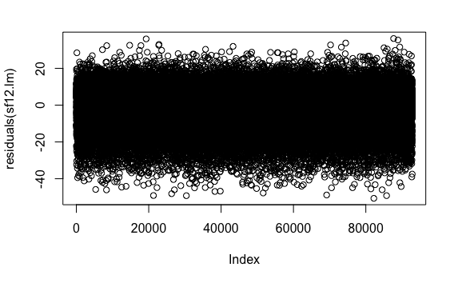

```r
plot(residuals(sf12.lm))
```

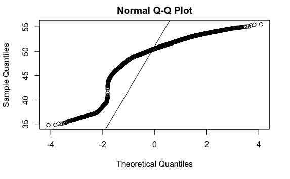

```r
qqnorm(predict(sf12.lm, test))
qqline(test$SF.12)
```

```r
data <- format_baseline_data("/Users/robertclay/paper1/data/corrected_US/", c(2013,2014,2015))
```

LASSO now

```r
# Preprocessing data.


data <- format_baseline_data("/Users/robertclay/paper1/data/corrected_US/", c(2011,2012,2013))
summary(data)
```

```
      pidp               SF.12          job_sec        education_state
 Min.   :2.244e+04   Min.   : 0.00   Min.   :-10.000   Length:129406
 1st Qu.:3.679e+08   1st Qu.:43.99   1st Qu.:-10.000   Class :character
 Median :7.080e+08   Median :51.77   Median :  3.000   Mode  :character
 Mean   :7.694e+08   Mean   :49.45   Mean   : -1.609
 3rd Qu.:1.157e+09   3rd Qu.:57.06   3rd Qu.:  5.000
 Max.   :1.653e+09   Max.   :78.08   Max.   :  8.000
                     NA's   :19997   NA's   :278
     sex            labour_state          region
 Length:129406      Length:129406      Length:129406
 Class :character   Class :character   Class :character
 Mode  :character   Mode  :character   Mode  :character




  ethnicity              age              time      gross_hh_income
 Length:129406      Min.   : 16.00   Min.   :2011   Min.   :-15967
 Class :character   1st Qu.: 34.00   1st Qu.:2011   1st Qu.:  1867
 Mode  :character   Median : 48.00   Median :2012   Median :  3113
                    Mean   : 48.19   Mean   :2012   Mean   :  3771
                    3rd Qu.: 62.00   3rd Qu.:2013   3rd Qu.:  4906
                    Max.   :104.00   Max.   :2013   Max.   :735592
                    NA's   :4
```

```r
# Rescale continuous variables
scaled_variables <- c("age", "gross_hh_income", "SF.12")
data[,scaled_variables] <- scale(data[,scaled_variables])

# Convert discrete variables to factors.
data <- tidyr::drop_na(data)
n <- nrow(data)
set.seed(88)
Inx <- sample(n, 0.8*n)
train <-data[Inx,]
train <- train[order(train$pidp, train$time),]
test <-data[-Inx,]
test <- test[order(train$pidp, train$time),]

y <- train$SF.12
y2<- test$SF.12

x <- model.matrix(SF.12 ~ (factor(sex) +
               factor(ethnicity) +
               age +
               factor(education_state) +
               factor(labour_state) +
               factor(job_sec) +
               factor(region) +
               gross_hh_income),
               data=train)


# Fit LASSO
lasso <- glmnet(x, y, alpha = 1, family = "gaussian")
cv.lasso <- cv.glmnet(x, y, alpha = 1, family = "gaussian")


# Plot LASSO
pdf("../plots/lasso_coefficients.pdf")
plot(lasso, xvar = "lambda", label = T)
abline(v = log(cv.lasso$lambda.min), col = "blue",lty=2)
abline(v = log(cv.lasso$lambda.1se), col = "red")
#text(-7.34, 1.6, "Minimum error", col="blue")
#text(-4.75, 1.6, "1 standard error", col="red")
dev.off()
```

```r
pdf("../plots/sf12_lasso_cv.pdf")
```

```r
plot(cv.lasso)
dev.off()
```

```r
coef(cv.lasso, s = "lambda.min")
```

```
50 x 1 sparse Matrix of class "dgCMatrix"
                                                  s1
(Intercept)                             -0.040955320
(Intercept)                              .
factor(sex)Male                          0.185731879
factor(ethnicity)BLA                     0.146379535
factor(ethnicity)BLC                     .
factor(ethnicity)CHI                     .
factor(ethnicity)IND                     0.026035118
factor(ethnicity)MIX                    -0.089573201
factor(ethnicity)OAS                    -0.040948770
factor(ethnicity)OBL                     0.034082069
factor(ethnicity)OTH                     .
factor(ethnicity)PAK                    -0.059770582
factor(ethnicity)WBI                     .
factor(ethnicity)WHO                     .
age                                      0.146935265
factor(education_state)CSE              -0.002668079
factor(education_state)Degree            .
factor(education_state)GCSE              0.029498748
factor(education_state)HE Diploma        0.017646163
factor(education_state)Higher Degree     0.029140384
factor(education_state)Less than GCSE   -0.053741321
factor(labour_state)Family Care         -0.178580919
factor(labour_state)Government Training  .
factor(labour_state)Maternity Leave      0.036629510
factor(labour_state)Other               -0.192153308
factor(labour_state)Retired              0.064108423
factor(labour_state)Self-employed        0.024722864
factor(labour_state)Sick/Disabled       -1.248930237
factor(labour_state)Student              0.015297038
factor(labour_state)Unemployed          -0.438979653
factor(job_sec)1                         0.003305541
factor(job_sec)2                         .
factor(job_sec)3                        -0.019214723
factor(job_sec)4                         .
factor(job_sec)5                         0.061018946
factor(job_sec)6                         0.070558250
factor(job_sec)7                         0.032508074
factor(job_sec)8                         0.051558247
factor(region)East of England            0.028166880
factor(region)London                    -0.039990001
factor(region)North East                -0.051631384
factor(region)North West                -0.013769107
factor(region)Northern Ireland           0.053320559
factor(region)Scotland                   0.029164367
factor(region)South East                 .
factor(region)South West                 0.023777566
factor(region)Wales                      .
factor(region)West Midlands             -0.038894054
factor(region)Yorkshire and The Humber   .
gross_hh_income                          0.049876485
```

```r
coef(cv.lasso, s = "lambda.1se")
```

```
50 x 1 sparse Matrix of class "dgCMatrix"
                                                 s1
(Intercept)                             -0.01098444
(Intercept)                              .
factor(sex)Male                          0.14964758
factor(ethnicity)BLA                     .
factor(ethnicity)BLC                     .
factor(ethnicity)CHI                     .
factor(ethnicity)IND                     .
factor(ethnicity)MIX                     .
factor(ethnicity)OAS                     .
factor(ethnicity)OBL                     .
factor(ethnicity)OTH                     .
factor(ethnicity)PAK                     .
factor(ethnicity)WBI                     .
factor(ethnicity)WHO                     .
age                                      0.12583962
factor(education_state)CSE               .
factor(education_state)Degree            .
factor(education_state)GCSE              .
factor(education_state)HE Diploma        .
factor(education_state)Higher Degree     .
factor(education_state)Less than GCSE    .
factor(labour_state)Family Care         -0.12358233
factor(labour_state)Government Training  .
factor(labour_state)Maternity Leave      .
factor(labour_state)Other                .
factor(labour_state)Retired              0.01211654
factor(labour_state)Self-employed        .
factor(labour_state)Sick/Disabled       -1.15226711
factor(labour_state)Student              .
factor(labour_state)Unemployed          -0.36775402
factor(job_sec)1                         .
factor(job_sec)2                         .
factor(job_sec)3                         .
factor(job_sec)4                         .
factor(job_sec)5                         .
factor(job_sec)6                         .
factor(job_sec)7                         .
factor(job_sec)8                         .
factor(region)East of England            .
factor(region)London                     .
factor(region)North East                 .
factor(region)North West                 .
factor(region)Northern Ireland           .
factor(region)Scotland                   .
factor(region)South East                 .
factor(region)South West                 .
factor(region)Wales                      .
factor(region)West Midlands              .
factor(region)Yorkshire and The Humber   .
gross_hh_income                          0.02181578
```

```r
lasso.1se <- glmnet(x, y, alpha = 1, family = "gaussian", lambda=cv.lasso$lambda.1se)
tLL <- lasso.1se$nulldev - deviance(lasso.1se)
k <- lasso.1se$df
n <- lasso.1se$nobs
AICc <- -tLL+2*k+2*k*(k+1)/(n-k-1)
AICc
```

```
[1] -8591.843
```

```r
# note the type = "class" is preferable here.
# the choice of a cutoff at p=0.5 is very arbitrary and this function helps
# to optimise the position of that line.
# For the the bubble plot is best for visual interpretation.
```

# Heterogeneity

```r
dep.gee <- geeglm(SF.12 ~ factor(sex) +
               factor(ethnicity) +
               age +
               factor(education_state) +
               factor(labour_state) +
               factor(job_sec) +
               factor(region) +
               gross_hh_income + 1:pidp , data = train, family = gaussian,id=pidp
              , corstr="ar1")

print(summary(dep.gee))
```

```
Call:
geeglm(formula = SF.12 ~ factor(sex) + factor(ethnicity) + age +
    factor(education_state) + factor(labour_state) + factor(job_sec) +
    factor(region) + gross_hh_income + 1:pidp, family = gaussian,
    data = train, id = pidp, corstr = "ar1")

 Coefficients:
                                          Estimate    Std.err    Wald
(Intercept)                             -0.1735973  0.0498740  12.115
factor(sex)Male                          0.1926798  0.0083970 526.526
factor(ethnicity)BLA                     0.2083812  0.0492661  17.890
factor(ethnicity)BLC                     0.0444870  0.0518314   0.737
factor(ethnicity)CHI                     0.0292596  0.0721289   0.165
factor(ethnicity)IND                     0.0845396  0.0471178   3.219
factor(ethnicity)MIX                    -0.0764918  0.0534608   2.047
factor(ethnicity)OAS                    -0.0136762  0.0543579   0.063
factor(ethnicity)OBL                     0.1561438  0.1072123   2.121
factor(ethnicity)OTH                     0.0419419  0.0780878   0.288
factor(ethnicity)PAK                    -0.0133570  0.0504175   0.070
factor(ethnicity)WBI                     0.0393954  0.0415534   0.899
factor(ethnicity)WHO                     0.0224858  0.0454745   0.245
age                                      0.1519960  0.0065138 544.502
factor(education_state)CSE              -0.0226252  0.0253714   0.795
factor(education_state)Degree            0.0242946  0.0157177   2.389
factor(education_state)GCSE              0.0453954  0.0138575  10.731
factor(education_state)HE Diploma        0.0421420  0.0180039   5.479
factor(education_state)Higher Degree     0.0637630  0.0167335  14.520
factor(education_state)Less than GCSE   -0.0496708  0.0152789  10.569
factor(labour_state)Family Care         -0.1089137  0.0266831  16.661
factor(labour_state)Government Training -0.0698757  0.1180373   0.350
factor(labour_state)Maternity Leave      0.0944686  0.0376902   6.282
factor(labour_state)Other               -0.1429024  0.0561326   6.481
factor(labour_state)Retired              0.1057872  0.0239148  19.567
factor(labour_state)Self-employed        0.0272343  0.0179838   2.293
factor(labour_state)Sick/Disabled       -0.9679188  0.0342919 796.699
factor(labour_state)Student              0.0776446  0.0230641  11.333
factor(labour_state)Unemployed          -0.2956424  0.0274715 115.816
factor(job_sec)1                         0.0934277  0.0317666   8.650
factor(job_sec)2                         0.0877385  0.0278285   9.940
factor(job_sec)3                         0.0489330  0.0235591   4.314
```

[output cut: 57 more lines]

```
factor(region)North East                0.005095 **
factor(region)North West                0.218892
factor(region)Northern Ireland          0.001402 **
factor(region)Scotland                  0.151413
factor(region)South East                0.538849
factor(region)South West                0.180082
factor(region)Wales                     0.821321
factor(region)West Midlands             0.021651 *
factor(region)Yorkshire and The Humber  0.975220
gross_hh_income                         0.136280
---
Signif. codes:  0 ‘***’ 0.001 ‘**’ 0.01 ‘*’ 0.05 ‘.’ 0.1 ‘ ’ 1

Correlation structure = ar1
Estimated Scale Parameters:
```

|  | Estimate | Std.err |
| --- | --- | --- |
| (Intercept) | 0.898 | 0.00639 |

```
  Link = identity

Estimated Correlation Parameters:
```

|  | Estimate | Std.err |
| --- | --- | --- |
| alpha | 0.557 | 0.00489 |

```
Number of clusters:   43420  Maximum cluster size: 3
```

```r
print(QIC(dep.gee))
```

```
  QIC
87238
```

```r
dep.glmm <- lmer(SF.12  ~  factor(sex) +
               factor(ethnicity) +
               age +
               factor(education_state) +
               factor(labour_state) +
               factor(job_sec) +
               factor(region) +
               gross_hh_income +
                (1|pidp), data = train)


glmm.sum <- summary(dep.glmm)
AIC(dep.glmm)
```

```
[1] 223758
```

```r
r.squaredGLMM(dep.glmm)
```

```
        R2m   R2c
[1,] 0.0842 0.563
```